# Week 6

Shawn Wang

2026-02-19

# Cleaning Genie

```r
jamie_genie <- function(dat, wordcol, omit_stops = TRUE, lemmatize = TRUE) {
  library(dplyr)
  library(tidyr)
  library(stringr)
  library(stringi)

  # Input validation
  #need to tell R what column in your dataframe is the text in quotes 'wordcol', this error message checks
  if (!wordcol %in% names(dat)) {
    stop(paste("Column", wordcol, "not found in dataframe"))
  }

#load stopword and replacement lists from github
load(url("https://github.com/Reilly-ConceptsCognitionLab/reillylab_publicdata/blob/main/Temple_stops25.rda?raw=true"))
load(url("https://github.com/Reilly-ConceptsCognitionLab/reillylab_publicdata/blob/main/replacements_25.rda?raw=true"))


# Create working copy and perform initial split, standardizes text encoding so all characters are UTF8, adds an id variable
# transform all text to lower
  dat_prep <- dat %>% dplyr::mutate(id_row_orig = factor(seq_len(nrow(dat))),
      text_initialsplit = tryCatch(stringi::stri_enc_toutf8(as.character(.[[wordcol]]),
                                 is_unknown_8bit = TRUE,
                                 validate = TRUE), error = function(e) stringi::stri_encode(as.character(.[[wordcol]]), to = "UTF-8")
      ) %>% tolower())

  # Standardize apostrophes in original text
  dat_prep <- dat_prep %>% dplyr::mutate(text_initialsplit = ifelse(
        is.na(text_initialsplit), NA_character_, stringi::stri_replace_all_regex(
          text_initialsplit,
          "[\u2018\u2019\u02BC\u201B\uFF07\u0092\u0091\u0060\u00B4\u2032\u2035]",
          "'"
        )
      )
    )

  # Perform initial split into words (retains contractions)
  dat_prep <- dat_prep %>% tidyr::separate_rows(text_initialsplit, sep = "[[:space:]]+") %>%
    dplyr::mutate(
      text_initialsplit = ifelse(
        is.na(text_initialsplit) | stringi::stri_isempty(text_initialsplit),
        NA_character_,
        text_initialsplit
      )
    ) %>%
    # Remove original column
    dplyr::select(-all_of(wordcol))

  # Initialize cleaning column with actual cleaned text
  dat_prep <- dat_prep %>%
    dplyr::mutate(
      word_clean = text_initialsplit,
      # Remove non-alphabetic characters except apostrophes
      word_clean = ifelse(
        is.na(word_clean),
        NA_character_,
        stringi::stri_replace_all_regex(word_clean, "[^a-zA-Z']", " ")
      ),
      # Squish whitespace
      word_clean = ifelse(
        is.na(word_clean),
        NA_character_,
        stringr::str_squish(word_clean)
      ),
      word_clean = ifelse(
        is.na(word_clean),
        NA_character_,
        stringi::stri_replace_all_regex(word_clean, "[^a-z']", "")
      ),
      word_clean = ifelse(
        is.na(word_clean),
        NA_character_,
        stringi::stri_replace_all_regex(word_clean, "[^[:alnum:]']", "")
      )
    )

#Replace words function - this finds contractions and replaces them with their expanded forms from a lookup database.
 replace_words <- function(word_clean, replacement_df) {
 for (i in seq_len(nrow(replacement_df))) {
   text_vector <- gsub(
     pattern = replacement_df$word[i],
     replacement = replacement_df$replacement[i],
     x = word_clean, ignore.case = TRUE)
 }
 return(word_clean)
 }

 #run replace words function on dat_prep
dat_prep <- replace_words(dat_prep, replacement_df = replacements_25)



  # Perform additional splitting after replacements (keeping NAs)
  dat_prep <- dat_prep %>%
    tidyr::separate_rows(word_clean, sep = "[[:space:]]+", convert = TRUE) %>%
    dplyr::mutate(
      word_clean = ifelse(
        is.na(word_clean) | stringi::stri_isempty(word_clean),
        NA_character_,
        word_clean
      ),
      id_row_postsplit = seq_len(dplyr::n())  # Fixed this line
    )

  # Lemmatization if requested (only for non-NA values)
  if (lemmatize) {
    dat_prep <- dat_prep %>%
      dplyr::mutate(
        word_clean = ifelse(
          is.na(word_clean),
          NA_character_,
          textstem::lemmatize_strings(word_clean)
        )
      )
  }

  # Stopword removal if requested (now keeps NAs)
  if (omit_stops) {
    stopwords <- tolower(Temple_stops25$word)
    dat_prep <- dat_prep %>%
      dplyr::mutate(
        is_stopword = ifelse(
          is.na(word_clean),
          NA,
          word_clean %in% stopwords
        ),
        word_clean = ifelse(is_stopword, NA_character_, word_clean)
      ) %>%
      dplyr::select(-is_stopword)  # Remove the is_stopword column
  }

  return(dat_prep)
}
```

# Hypotheses

I am hypothesizing that the level of anger the definition of gaslighting and level of anger in the story about gaslighting will be positively correlated–i.e. that increases in anger in one’s definition of gaslighting will be associated with increases in anger in the stories about gaslighting. I will test this by processing each corpus separately, generating values of anger for each, and using a linear regression to investigate the relationship between anger scores between the two.

# Sample Characteristics

```r
gaslight %>%
  group_by(Gender) %>% #group by gender to get values per group
  dplyr::summarize(n = n(), #raw counts
                   Percentage = round(n()/1034, 2)) %>% #percentage
  kable()
```

| Gender | n | Percentage |
| --- | --- | --- |
|  | 23 | 0.02 |
| Female | 817 | 0.79 |
| Male | 194 | 0.19 |

```r
gaslight %>%
  group_by(Gender) %>%
  dplyr::summarize(`Mean Age` = mean(Age, na.rm = TRUE),
                   `Age SD` = sd(Age, na.rm = TRUE)) %>%
  kable()
```

| Gender | Mean Age | Age SD |
| --- | --- | --- |
|  | 20.52381 | 3.140367 |
| Female | 19.57908 | 2.041871 |
| Male | 20.17460 | 2.225622 |

# Data Preparation/Cleaning

To prepare the data, I will:

1. Load in the dataset from github
2. Split the dataset into two data frames, one for the stories and one for the definitions
3. Run the cleaning genie separately on both, removing stopwords and lemmatizing
- I am removing stopwords because I believe they are not relevant to the research question
- Similarly, I do not believe the tenses or morphology of the words are relevant
4. After cleaning, I will then further clean each dataset by filtering to only non-NA cleaned word rows.
- I will also retain only the ID and cleaned word columns
5. For each data frame separately, I will assign anger values to each word using the lookup database
6. I will generate anger values per person by averaging across the anger of all their words for both story and definition separately, thus creating a data frame for each that is a single row and anger value per person
7. Finally, I will join these data frames back together by ID

```r
#load in the lookup database
lookup_small <- lookup_Jul25 %>%
  select(word, emo_anger)


#clean each dataset separately
gaslight_story <- gaslight %>%
  select(ID, gd_adult_story)
gaslight_def <- gaslight %>%
  select(ID, gd_adult_definition)


gaslight_story_clean <- jamie_genie(dat = gaslight_story, wordcol = "gd_adult_story") %>% #apply genie
  filter(!is.na(word_clean)) %>% #filter to only words kept
  rename("word_clean_story" = "word_clean") %>% #rename column so it doesn't merge with other set
  select(ID, word_clean_story) #select relevant columns
gaslight_def_clean <- jamie_genie(dat = gaslight_def, wordcol = "gd_adult_definition") %>%
  filter(!is.na(word_clean)) %>%
  rename("word_clean_def" = "word_clean") %>%
  select(ID, word_clean_def)


#join with the lookup table, keeping only words in our data
gaslight_story_anger <- left_join(gaslight_story_clean, lookup_small, by = c("word_clean_story" = "word")) %>% group_by(ID) %>% #calculate statistics per ID
  dplyr::summarize(mean_anger_story = mean(emo_anger, na.rm = TRUE)) #calculate mean anger scores

gaslight_def_anger <- left_join(gaslight_def_clean, lookup_small, by = c("word_clean_def" = "word")) %>% group_by(ID) %>%
  dplyr::summarize(mean_anger_def = mean(emo_anger, na.rm = TRUE))


#join both datasets together into full dataset
full_df <- full_join(gaslight_story_anger, gaslight_def_anger, by = "ID")
```

# Data Analysis

First, I want to look at the distributions of the angers between both story and definitions of gaslighting.

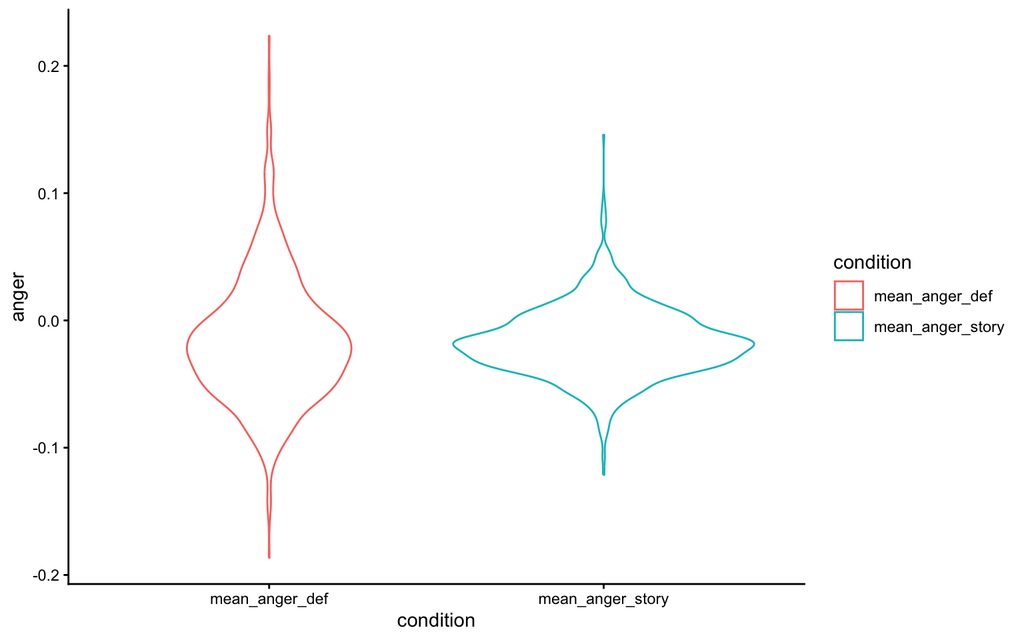

```r
#pivot longer so that there is one column condition with values mean_anger_def and mean_anger_story
#another column of anger values
#this is important for plotting
full_df %>%
  pivot_longer(cols = c(mean_anger_def, mean_anger_story),
               names_to = "condition", values_to = "anger") %>%
  ggplot(mapping = aes(x = condition, y = anger, group = condition, color = condition)) +
  geom_violin() + #violin plot
  theme_classic() #looks cleaner
```

In order to test my hypothesis, I will run a linear regression between anger of story and anger of definition.

```r
#run linear model
model <- lm(mean_anger_story ~ mean_anger_def, data = full_df)

#view results
summary(model)
```

```
##
## Call:
## lm(formula = mean_anger_story ~ mean_anger_def, data = full_df)
##
## Residuals:
##       Min        1Q    Median        3Q       Max
## -0.103614 -0.016215 -0.001267  0.015565  0.153301
##
## Coefficients:
##                  Estimate Std. Error t value Pr(>|t|)
## (Intercept)    -0.0158197  0.0008837 -17.903  < 2e-16 ***
## mean_anger_def  0.0685773  0.0172808   3.968 7.74e-05 ***
## ---
## Signif. codes:  0 '***' 0.001 '**' 0.01 '*' 0.05 '.' 0.1 ' ' 1
##
## Residual standard error: 0.02688 on 1026 degrees of freedom
##   (6 observations deleted due to missingness)
## Multiple R-squared:  0.01512,    Adjusted R-squared:  0.01416
## F-statistic: 15.75 on 1 and 1026 DF,  p-value: 7.739e-05
```

The model suggests that anger in the gaslighting story text is significantly positively associated with anger in the gaslighting definition (b = 0.07, SE = 0.02, t = 3.97, p < .001). This suggests that those who display more anger lexcially in their definition of gaslighting tend to also communicate more anger lexically in their stories of gaslighting. This makes sense as those who have more anger towards gaslighting as a concept and thus communicate more anger in their definition may have had previous negative experiences with gaslighting, and thus are more likely to be primed towards anger in their stories as well.

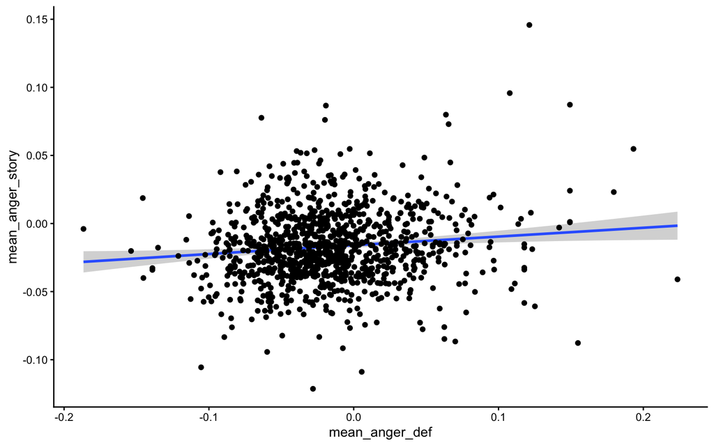

```r
full_df %>%
  ggplot(mapping = aes(x = mean_anger_def, y = mean_anger_story)) +
  geom_smooth() + geom_point() + #plot line plot and the scatterplot of data points
  theme_classic()
```

And when we look at a graphical display of the relationship between the two, we can notice this slight positive correlation between anger values from the two corpuses.

# Bonus Exploratory Analyses

Based on my interpretation of the previous model, I am curious whether the relationship between anger in the definition and the stories of gaslighting may be moderated by previous experiences with gaslighting. Thus, I will conduct a moderation analysis to assess this.

```r
#have to add in the new column for gaslighting history
gaslight_history <- gaslight %>%
  select(ID, Ever_Gaslit)
#new data frame with moderating variable
full_df_mod <- full_join(full_df, gaslight_history, by = "ID")


#fit the model with moderator
model2 <- lm(mean_anger_story ~ mean_anger_def*Ever_Gaslit, data = full_df_mod)
summary(model2)
```

```
##
## Call:
## lm(formula = mean_anger_story ~ mean_anger_def * Ever_Gaslit,
##     data = full_df_mod)
##
## Residuals:
##       Min        1Q    Median        3Q       Max
## -0.103799 -0.015974 -0.001331  0.015726  0.152073
##
## Coefficients:
##                                Estimate Std. Error t value Pr(>|t|)
## (Intercept)                   -0.017000   0.001843  -9.222   <2e-16 ***
## mean_anger_def                 0.047456   0.035949   1.320    0.187
## Ever_GaslitYes                 0.001562   0.002102   0.743    0.458
## mean_anger_def:Ever_GaslitYes  0.028107   0.041016   0.685    0.493
## ---
## Signif. codes:  0 '***' 0.001 '**' 0.01 '*' 0.05 '.' 0.1 ' ' 1
##
## Residual standard error: 0.02689 on 1024 degrees of freedom
##   (6 observations deleted due to missingness)
## Multiple R-squared:  0.0159, Adjusted R-squared:  0.01302
## F-statistic: 5.514 on 3 and 1024 DF,  p-value: 0.0009302
```

This additional analysis suggests that there is not a moderating effect of being gaslit in the past on the relationship between anger in the definition and story about gaslighting. Because of this, perhaps my original interpretation can be updated to reflect this new data. An alternative explanation could be that those who are generally angrier at a trait level are more likely to have their anger reflected in their language at a baseline level, and thus will have higher anger scores on both definition and story. However, we don’t have a measure of baseline anger to test this against so I cannot verify it at the moment.

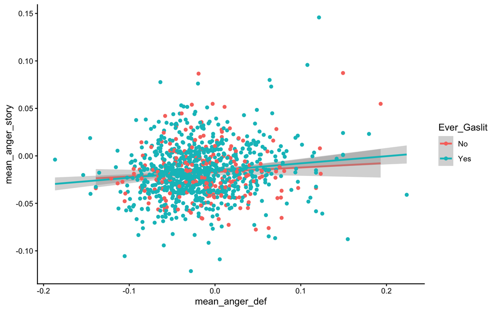

```r
full_df_mod %>%
  ggplot(mapping = aes(x = mean_anger_def, y = mean_anger_story, group = Ever_Gaslit, color = Ever_Gaslit)) +
  geom_smooth(method = "lm") + geom_point() + #plot line plot and the scatterplot of data points
  theme_classic()
```

And we can see from the scatterplot broken down by gaslighting exposure that the lines do not seem to differ too much, which supports the lack of moderation finding.